# Dube 2012w

### Experiment summary

22 subjects participated in five study-test cycles. Each cycle included 40 items presented at study and 80 during the test phase. The stimuli were 400 words, singular nouns, 5 to 8 letters long. Of the test phase stimuli, half were old (from the same study cycle) and half new. During the study phase 40 items were presented one at a time in random order. The study phase was followed by a recognition test phase that included the 40 most recently studied items and 40 new items, randomly intermixed. Subjects did not receive any feedback or intructions, they were simply asked to provide confidence ratings after each response (‘old’ or ‘new’). Ratings were made on a scale from 1 to 3, where 1 indicated the least confidence and 3 the most, resulting in a total of 6 possible response categories ranging from high-confidence ‘old’ to high-confidence ‘new’ responses.

### Some information on the models

**Model Original:** q_2 = q_5, & r_2 = r_5 (all but highest confidence response mapping of uncertainty and detection states equated)  
**Q restricted:** q_2 = q_5 (all but highest confidence response mapping of uncertainty states equated)  
**R restricted:** r_2 = r_5 (all but highest confidence response mapping of detection states equated)

### Some information on convergence

#### For Model Original

One approach failed: partial, TreeBUGS, beta

Frequentist approach with no pooling (asymptotic.no.MPTinR) had 0.682 as proportion of participants with non-identified parameters. Frequentist approach with complete pooling (asymptotic.complete.MPTinR) had no convergence problems.

Bayesian approach with no pooling (simple.no.TreeBUGS) and with complete pooling (simple.complete.TreeBUGS) both converged well, all Rhat < 1.05.  
Bayesian approach with partial pooling (trait.partial.Treebugs and trait_uncorrelated.partial.TreeBUGS) converged well, all Rhat < 1.05.

#### For Q restricted

One approach failed: partial, TreeBUGS, beta

Frequentist approach with no pooling (asymptotic.no.MPTinR) had 0.909 as proportion of participants with non-identified parameters. Frequentist approach with complete pooling (asymptotic.complete.MPTinR) had some convergence problems:  
rank.fischer = 4, n.parameters = 10, convergence = 0.

Bayesian approach with no pooling (simple.no.TreeBUGS) and with complete pooling (simple.complete.TreeBUGS) both converged well, all Rhat < 1.05.  
Bayesian approach with partial pooling (trait.partial.Treebugs and trait_uncorrelated.partial.TreeBUGS) converged well, all Rhat < 1.05.

#### For R restricted

One approach failed: partial, TreeBUGS, beta

Frequentist approach with no pooling (asymptotic.no.MPTinR) had 0.591 as proportion of participants with non-identified parameters. Frequentist approach with complete pooling (asymptotic.complete.MPTinR) had no convergence problems.

Bayesian approach with no pooling (simple.no.TreeBUGS) and with complete pooling (simple.complete.TreeBUGS) both converged well, all Rhat < 1.05.  
Bayesian approach with partial pooling (trait.partial.Treebugs and trait_uncorrelated.partial.TreeBUGS) converged well, all Rhat < 1.05.

### Parameter estimation

**Model Original**

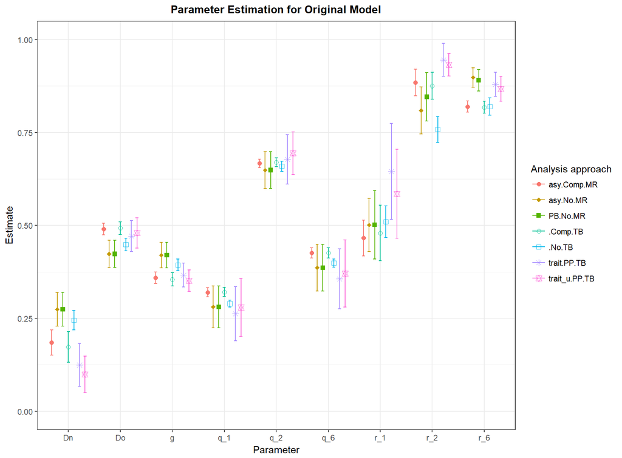

**Q restricted**

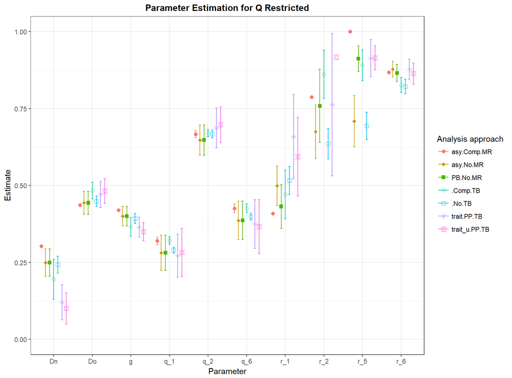

**R restricted**

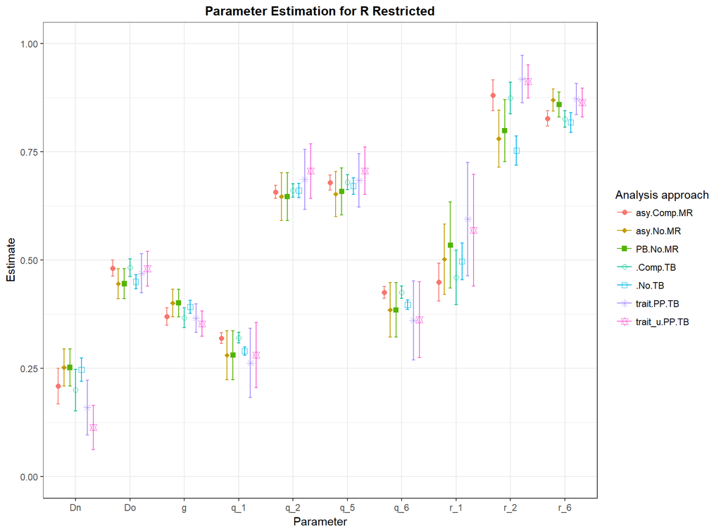

**Core parameters**

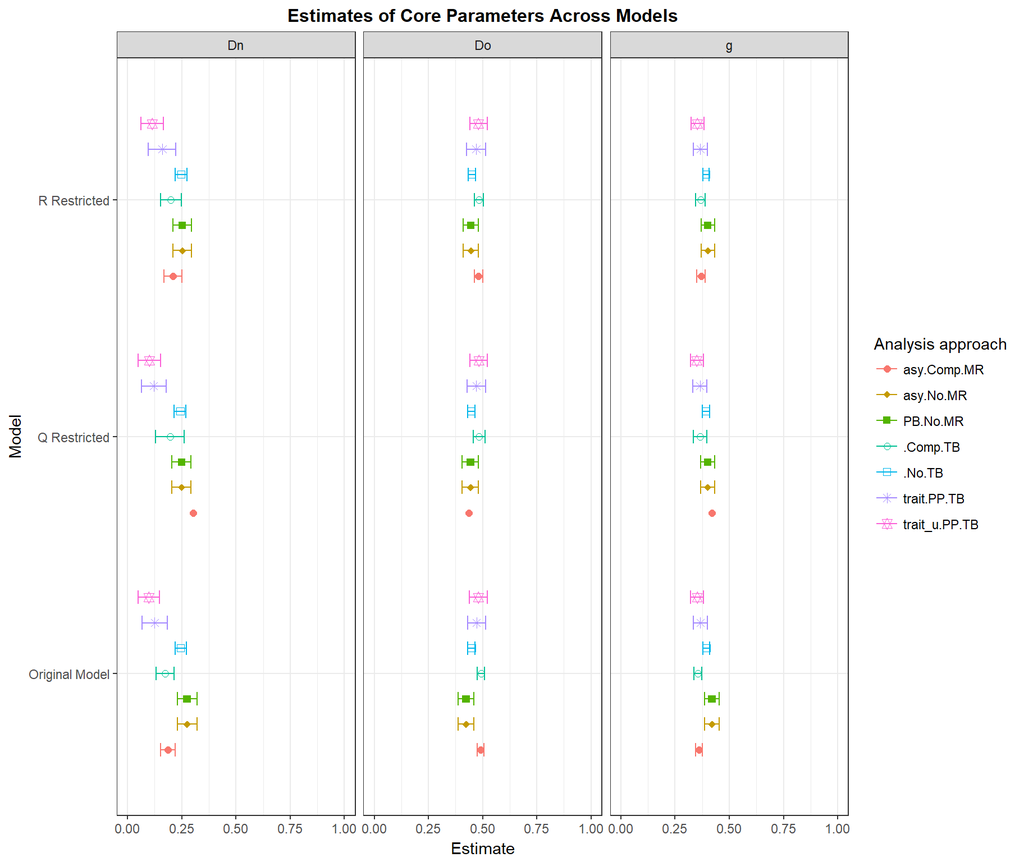

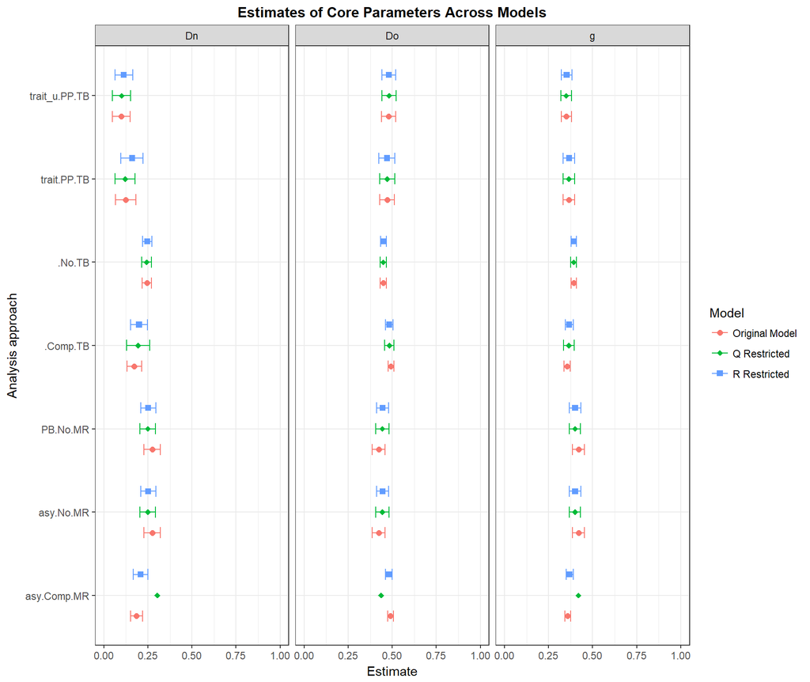

**Q parameters**

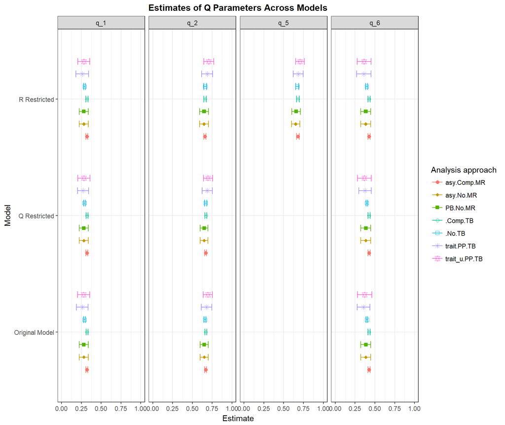

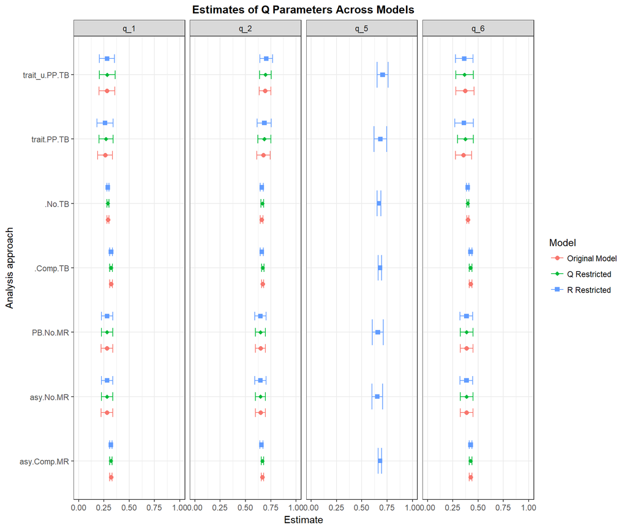

**R parameters**

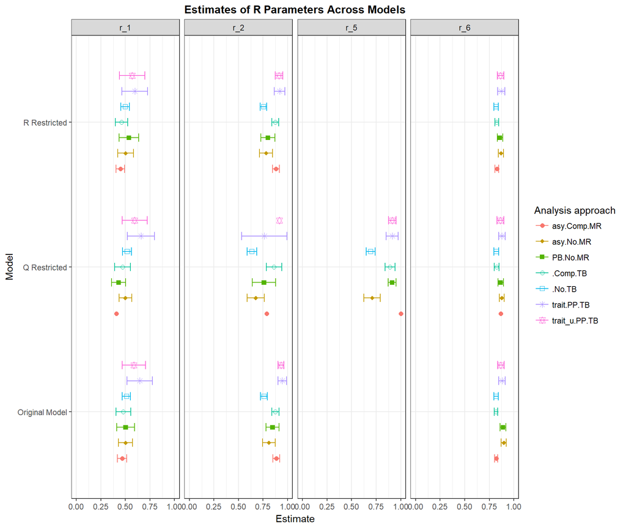

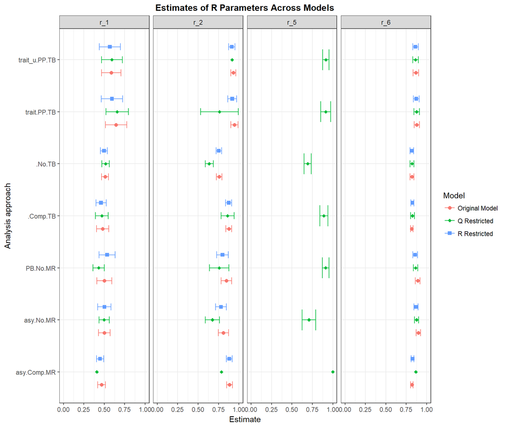

### Goodness of fit

**Model Original**

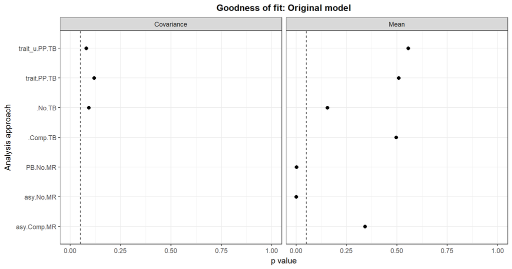

**Q restricted**

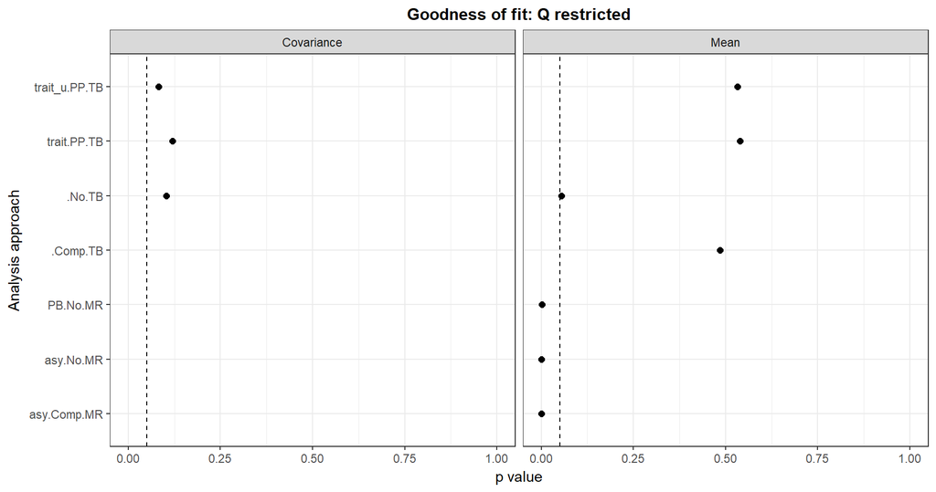

**R restricted**

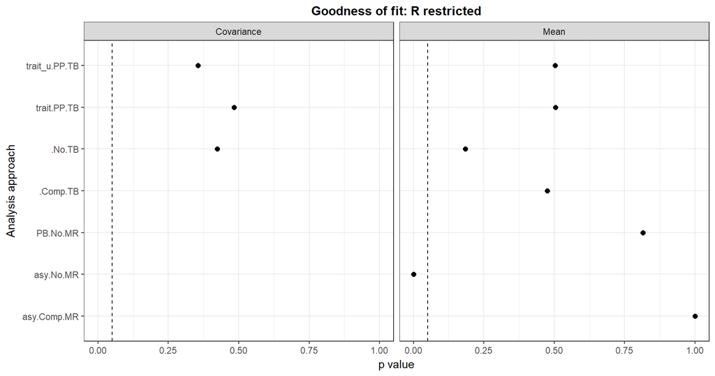